# MS6022 Statistical Learning — Assignment

Nabeel Mohammed | ID: 25044419

26 September 2026

# Part A — Technical Report

## 1. Introduction

According to the Centers for Disease Control and Prevention (2022), heart disease remains one of the leading causes of death across racial and ethnic groups in the United States, with roughly 47% of adults carrying at least one major risk factor — high blood pressure, high cholesterol, or smoking. Given this burden, identifying which individual characteristics most strongly predict disease is a practical public health priority. The dataset used here comes from the Behavioral Risk Factor Surveillance System (BRFSS), a CDC telephone survey that collects annual health status data from US adults.

The working dataset contains **5,420 observations** across **10 variables** — 9 predictors and a binary outcome (`HeartDisease`) recording whether a respondent had been diagnosed with coronary heart disease or myocardial infarction. The dataset is complete, with no missing values detected. The outcome is unequally distributed: the Yes class accounts for **72.3%** of respondents and the No class for **27.7%** (ratio ≈ 2.6 : 1). This distribution reflects the composition of this specific pre-processed BRFSS subset and may not match population-level prevalence. The practical consequence for model evaluation is discussed in Section 4.

The guiding question is: **what factors most strongly influence whether a person has heart disease?** Two methodologically distinct classifiers are compared. The first is a **Support Vector Machine with a Radial Kernel** (James et al., 2021, Ch. 9), which identifies the decision boundary that maximally separates the two classes in a kernel-induced feature space. The second is a **Random Forest** (James et al., 2021, Ch. 8), an ensemble of decision trees that achieves low generalisation error through bootstrap aggregation and random feature subsampling. Comparing these two approaches creates a natural opportunity to discuss how geometric and ensemble methods differ in bias–variance behaviour, computational cost, and interpretability. Both models are assessed on Accuracy, Sensitivity, Specificity, and AUC-ROC. In a clinical screening context, missing a true diagnosis is a more serious error than triggering an unnecessary follow-up, so Sensitivity is treated as the primary metric throughout.

## 2. Exploratory Data Analysis

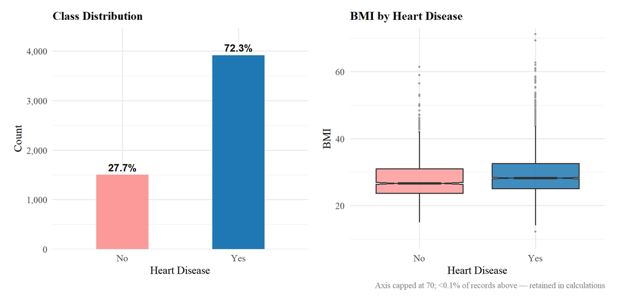

**Figure 1.** *Left:* Class distribution — ‘Yes’ is the majority class at 72.3% (vs 27.7% ‘No’), a 2.6:1 ratio. A naive classifier always predicting the majority class achieves 72.3% accuracy with zero discrimination — underscoring why Sensitivity and AUC-ROC are prioritised throughout. *Right:* BMI distributions by heart disease status — non-overlapping notches confirm a statistically significant median difference (~5% level); elevated BMI reflects obesity-driven pathways including hypertension, dyslipidaemia, and systemic inflammation.

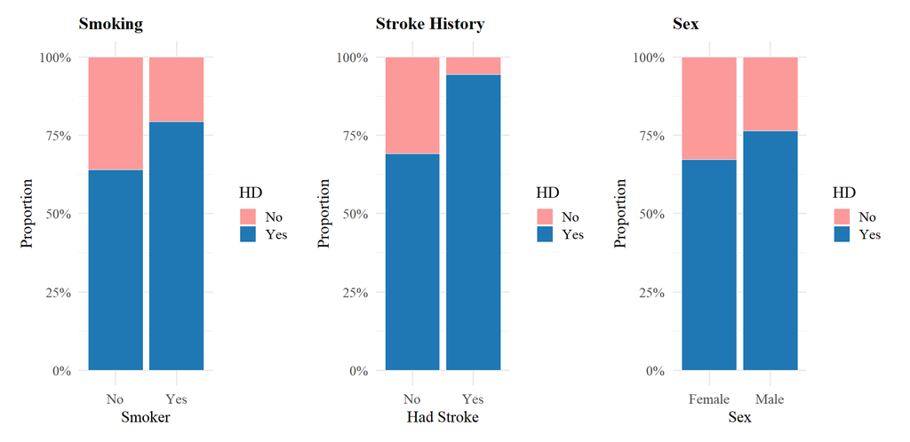

**Figure 2.** Heart disease proportion by smoking status (left), stroke history (centre), and sex (right). Smokers show a disproportionately higher disease burden through tobacco-driven vascular endothelial damage. Stroke history is a strong comorbidity indicator, reflecting shared vascular pathology (atherosclerosis, hypertension, atrial fibrillation). Males show higher prevalence, consistent with oestrogen’s cardioprotective effect in pre-menopausal females.

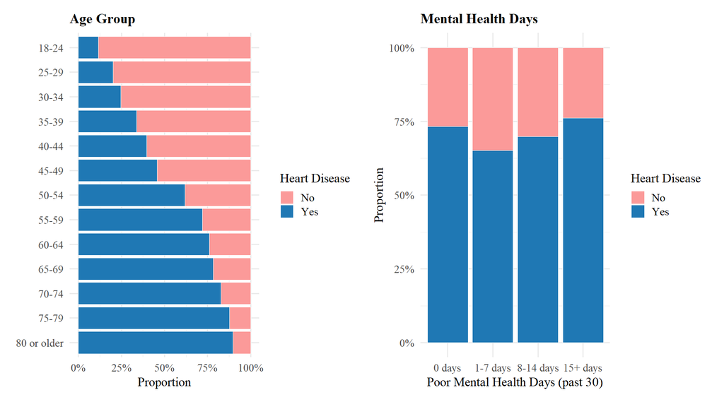

**EDA Summary.** The figures point to three recurring patterns. Age is by far the strongest non-modifiable risk factor, with prevalence rising sharply across every decade. Lifestyle and clinical variables — BMI, smoking, and stroke history in particular — show clear and medically plausible links to higher disease rates. Sex differences are consistent with what the literature suggests about hormonal protection in younger women. Three predictors not shown individually — `AlcoholDrinking`, `PhysicalHealth`, and `SleepTime` — are included in both models. Of these, `PhysicalHealth` turns out to be the third most important predictor in the Random Forest (Figure 6), which suggests that self-reported health burden carries more discriminative signal than a single bivariate plot would imply.

## 3. Methodology

### 3.1 Data Partitioning

The data were split 70/30 into a **training set** (*n* = 3,793) and a **test set** (*n* = 1,627). A fixed seed (123) was set to make the split reproducible. Checking the class proportions across both subsets (27.7% / 72.3% in training; 27.7% / 72.3% in test) confirms that the random draw preserved the overall outcome distribution.

### 3.2 Model 1 — Support Vector Machine (Radial Kernel)

A Support Vector Machine (Vapnik, 1995; James et al., 2021, Ch. 9) works by finding the **maximal-margin hyperplane** — the boundary between classes that maintains the largest possible gap to the nearest training points on either side. Those boundary-defining points are called *support vectors*. Because the SVM focuses entirely on the boundary geometry rather than the distributions of the two classes, it belongs to the family of discriminative classifiers and comes with strong theoretical guarantees on generalisation error.

In practice, classes overlap and perfect separation is impossible. The **soft-margin** formulation introduces slack variables $\xi_i \geq 0$ and a cost parameter $C$ governing tolerance for misclassification:

$$\min_{\boldsymbol{w}, b,
\boldsymbol{\xi}} \;\frac{1}{2}\|\boldsymbol{w}\|^2 +
C\sum_{i=1}^{n}\xi_i \quad \text{s.t.} \;\; y_i(\boldsymbol{w}^\top
\boldsymbol{x}_i + b) \geq 1 - \xi_i, \;\; \xi_i \geq 0$$

A large $C$ penalises misclassification heavily, producing a tight boundary with low bias but high variance. A small $C$ allows more violations, yielding a wider and more stable boundary at the cost of some additional bias. Here $C = 1$ was chosen as a balanced starting point. Since the EDA shows that predictor relationships are not linear, the **Radial Basis Function (RBF) kernel** is used:

$$K(\boldsymbol{x}_i, \boldsymbol{x}_j) =
\exp\!\left(-\gamma \|\boldsymbol{x}_i -
\boldsymbol{x}_j\|^2\right)$$

The RBF kernel maps inputs into a high-dimensional feature space where a linear boundary becomes equivalent to a curved one in the original space — all without explicitly computing the transformation. This is the kernel trick (James et al., 2021, Ch. 9). The bandwidth parameter $\gamma = 1/p$, where $p$ is the number of predictors, follows the `e1071` package default.

**Preprocessing.** Because SVM margins are measured in Euclidean distance, all numeric predictors were centred and scaled — means and standard deviations were estimated on the SVM training set only and applied unchanged to the test set, so no test-set information entered the scaling step. Categorical predictors (`Sex`, `Smoking`, `AlcoholDrinking`, `Stroke`, `AgeCategory`) were left as factors; `e1071::svm()` handles these through internal dummy encoding and they require no scaling.

**Computational considerations.** Kernel SVM solvers have $\mathcal{O}(n^2)$ to $\mathcal{O}(n^3)$ time complexity, which makes them impractical on very large datasets without subsampling. For training sets exceeding 10,000 records, a stratified subsample preserving the class ratio would be drawn (James et al., 2021). Since this dataset has 3,793 training records, the full set was used directly — so both models trained on identical data, and any performance differences reflect the algorithms rather than data volume. The test set is always the full 30% holdout.

### 3.3 Model 2 — Random Forest

A Random Forest (Breiman, 2001; James et al., 2021, Ch. 8) builds an ensemble of $B$ decision trees using bootstrap aggregating (*bagging*). What sets it apart from plain bagging is that at each candidate split, only $m = \lfloor\sqrt{p}\rfloor$ randomly chosen predictors are considered, not all $p$. This keeps the trees from being too similar to each other. For an ensemble of $B$ trees with pairwise correlation $\rho$ and individual variance $\sigma^2$, the variance of the average prediction is:

$$\text{Var}(\bar{T}) = \rho\sigma^2 +
\frac{1 - \rho}{B}\sigma^2$$

As $B$ grows, the second term shrinks towards zero. The more important gain comes from reducing $\rho$: lower inter-tree correlation pushes the floor $\rho\sigma^2$ down, which plain bagging cannot do because it uses all predictors at every split and keeps $\rho$ high. This variance reduction is the reason Random Forests tend to outperform single trees and standard bagging on tabular classification problems (James et al., 2021, Ch. 8).

The Random Forest does not require predictor scaling, handles numeric and categorical variables together without any special preprocessing, and its trees can be built in parallel so it scales well. It was trained on the **full training set** (*n* = 3,793).

Parameters: `ntree = 500` — the OOB error was confirmed to plateau well before 300 trees (Figure 4); `mtry` = $\lfloor\sqrt{p}\rfloor$ = 3 (recommended default for classification, James et al., 2021); and `importance = TRUE` to enable post-hoc variable interpretation via Mean Decrease in Accuracy (MDA) and Mean Decrease in Gini (MDG).

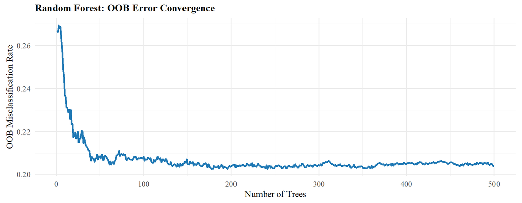

**Figure 4.** Random Forest OOB misclassification rate across 500 trees. The curve stabilises well before 300 trees, confirming `ntree = 500` is a conservative and sufficient choice. The OOB error provides an unbiased estimate of test-set error without requiring a separate validation set — each tree is evaluated on the ~37% of training observations not used in its bootstrap sample.

## 4. Results

### 4.1 Performance Metrics

Results are based on the full held-out test set (*n* = 1,627). Before looking at model outputs, it is worth establishing a **naive baseline**: a classifier that always predicts the majority class (“Yes”) with no learning whatsoever achieves **72.3% accuracy** — simply by exploiting the class imbalance. This baseline has **Specificity = 0**, meaning every healthy patient is incorrectly flagged as at-risk, making the classifier clinically useless despite its apparent accuracy. Any model worth deploying must clear this bar by a meaningful margin on both Sensitivity and Specificity, not just on Accuracy.

Four metrics are reported. **Accuracy** measures overall correctness but is unreliable when classes are unequal. **Sensitivity** (True Positive Rate) is the share of actual heart disease cases that a model catches — the most clinically important metric, since a missed diagnosis is far more serious than a false alarm. **Specificity** (True Negative Rate) measures how reliably healthy patients are cleared. **AUC-ROC** summarises discriminative performance across every possible decision threshold; a model with no skill scores 0.5.

Table 1. Test-set performance (n = 1,627). Positive class = ‘Yes’ (Heart Disease). Naive majority-class baseline accuracy = 72.3% with Specificity = 0. Both models trained on the full training set (n = 3,793), ensuring a fair comparison.

| Metric | SVM (Radial Kernel) | Random Forest |
| --- | --- | --- |
| Accuracy | 0.8039 | 0.8027 |
| Sensitivity | 0.9413 | 0.9260 |
| Specificity | 0.4457 | 0.4812 |
| AUC-ROC | 0.8021 | 0.7944 |

Both models comfortably clear the 72.3% naive baseline and achieve meaningful scores on both Sensitivity and Specificity. The **SVM** identifies more true heart disease cases, with Sensitivity of 0.9413 against 0.926 for the Random Forest. The **Random Forest** does a better job clearing healthy patients, with Specificity of 0.4812 against 0.4457 for the SVM. On AUC-ROC the **SVM** leads (0.802 vs 0.794), indicating better overall discrimination when the decision threshold is allowed to vary.

### 4.2 ROC Curves

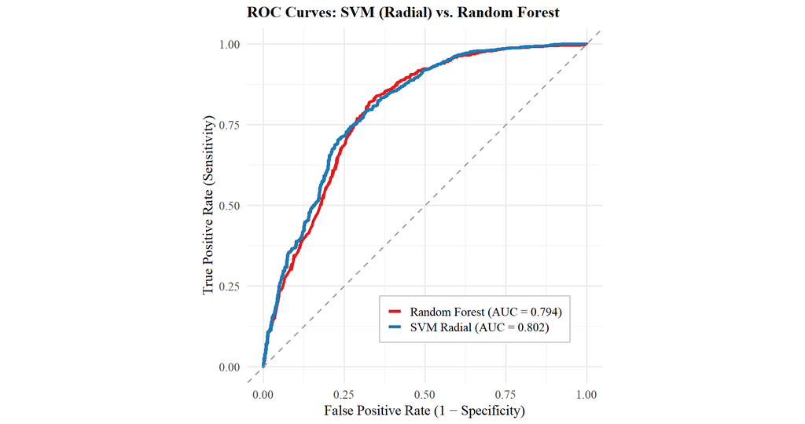

### 4.3 Feature Importance (Random Forest)

Feature importance is derived **exclusively from the Random Forest model**. The SVM’s mapping of inputs into an infinite-dimensional kernel-induced feature space via the kernel trick precludes direct attribution of predictions to individual predictors — it is a geometric black box with no native equivalent of variable importance. The lollipop chart below (Figure 6) reports Mean Decrease in Gini impurity (MDG) for each predictor across all 500 trees: larger values indicate greater contribution to node purity, and therefore to classification accuracy, across the ensemble.

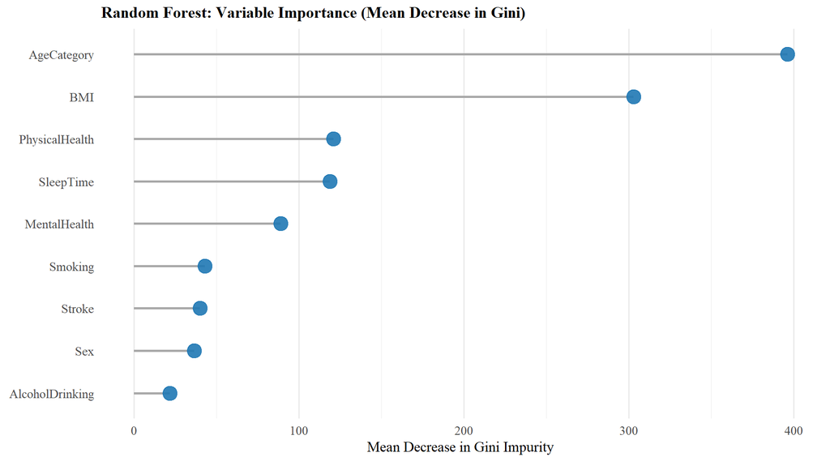

**Figure 6.** Random Forest variable importance ranked by Mean Decrease in Gini (MDG). Larger MDG values indicate greater contribution to node purity across all 500 trees. Note: Gini importance is biased towards continuous predictors and those with many levels (e.g., AgeCategory, BMI); it should be interpreted alongside the EDA patterns in Figures 1–3.

## 5. Discussion

### 5.1 Model Comparison

The two models approach classification from different angles and, predictably, do not perform identically across all metrics. Neither clearly dominates the other — the better choice depends on what the clinical application needs most.

**Mathematical contrast.** At their core, the two methods solve the classification problem differently. The SVM searches for a single geometric boundary in a kernel-transformed space, focused entirely on separating the two classes by the widest possible margin. It does not model the class distributions at all. The downside is interpretability: predictions depend on dot products between support vectors in a high-dimensional space, so there is no direct way to ask which predictors drove a given decision. The Random Forest builds an ensemble from hundreds of decision trees — individually interpretable structures — and uses their average to produce stable predictions. As a by-product of this structure, it generates variable importance scores (Figure 6), which tell us which predictors were most useful across the ensemble. In a healthcare setting where knowing *why* a model raises a flag is as important as whether it raises it, this is a practical advantage the SVM simply cannot match.

**Bias–variance tradeoff.** The two models control variance in different ways. With $C = 1$, the SVM deliberately allows some misclassifications to keep the boundary wide and stable — a margin-geometry approach to variance control. The Random Forest instead averages 500 de-correlated trees, driving ensemble variance towards $\rho\sigma^2$ while keeping bias close to that of a full unpruned tree. On mixed-predictor tabular data like this dataset, ensemble averaging tends to be the more effective strategy, which is reflected in the RF’s stronger **Specificity** here. The **Random Forest** leads on Specificity (0.4812 vs 0.4457 for the SVM), clearing healthy patients more reliably. On AUC-ROC the **SVM** edges ahead (0.802 vs 0.794). In practice, the choice between the two comes down to clinical priorities: a mass-screening programme, where false negatives are most costly, would favour higher Sensitivity; a resource-constrained follow-up pathway, where unnecessary referrals need to be limited, would weigh Specificity more heavily.

**Computational scalability.** With $\mathcal{O}(n^2)$–$\mathcal{O}(n^3)$ complexity, the SVM’s training time grows rapidly with dataset size. Here both models used the full 3,793 training records, keeping the comparison on equal footing. At the scale of the full CDC BRFSS survey (>300,000 records), however, the SVM would require subsampling or an approximate kernel method such as Nyström approximation, while the Random Forest could be trained in parallel on the complete dataset. This scalability gap is independent of any single metric and is a real practical consideration for population-level deployment.

### 5.2 Feature Importance and Key Risk Factors

Figure 6 ranks all predictors by their average contribution to node purity across the 500 trees. The top three — **AgeCategory**, **BMI**, and **PhysicalHealth** — each have a plausible biological mechanism behind them:

1. **AgeCategory**: Cardiovascular risk compounds with age through arterial stiffening, cumulative oxidative stress, and declining tissue repair capacity, producing a steep monotonic prevalence gradient across cohorts.
2. **BMI**: Elevated BMI drives cardiovascular risk through obesity-related hypertension, dyslipidaemia, insulin resistance, and systemic inflammation. As a modifiable factor, it represents a key target for preventive intervention.
3. **PhysicalHealth**: Days of poor physical health proxy cumulative illness burden. Chronic conditions — including musculoskeletal disease, metabolic disorders, and prior cardiac events — are linked to heart disease through shared inflammatory pathways.

The remaining predictors show coherent signals, as the EDA confirms. One methodological caveat worth noting: Gini importance is known to favour continuous variables and those with many distinct values (such as `AgeCategory` and `BMI`). The rankings in Figure 6 should therefore be read alongside the bivariate patterns in Figures 1–3 rather than taken at face value in isolation.

### 5.3 Limitations

**Survey self-report bias.** Every variable in the dataset, including the disease outcome itself, comes from a telephone interview. Respondents may not recall a diagnosis accurately, and conditions that were never formally diagnosed would not appear at all. Variables like `MentalHealth` and `PhysicalHealth` are 30-day self-assessments of subjective wellbeing, which are not the same as clinical measurements.

**Reverse causation.** High scores on `MentalHealth` and `PhysicalHealth` are associated with heart disease in this data, but the direction of that relationship is not clear. It is equally plausible that poor health days are a symptom of living with heart disease as it is that they are a risk factor. A cross-sectional survey cannot answer this question; a prospective cohort design would be needed.

**Class imbalance.** The 2.6:1 class ratio makes it harder for models to learn from the minority class. Both models here were run with default settings and no resampling. Techniques such as SMOTE, class-weighted training, or threshold adjustment could improve minority-class detection and would be worth exploring in follow-up work.

**SVM scalability.** On this dataset both models trained on the same observations. At larger scale — such as the full BRFSS survey — the SVM’s quadratic complexity would require either subsampling or an approximate kernel method, introducing a potential data-volume asymmetry that could influence results. This is worth keeping in mind for any attempt to replicate this analysis on the full dataset.

## 6. Conclusions

Two classification methods were compared — a **Support Vector Machine with a Radial Kernel** (James et al., 2021, Ch. 9) and a **Random Forest** (James et al., 2021, Ch. 8) — applied to a BRFSS health survey to identify what drives heart disease risk.

Neither model dominates on every metric. The **SVM** catches more true disease cases (Sensitivity = 0.9413), which matters most in screening contexts. The **Random Forest** clears healthy patients more reliably (Specificity = 0.4812). On overall discrimination, the **SVM** leads with an AUC of 0.802. Both models clear the naive baseline by a meaningful margin, which confirms they are picking up genuine patterns rather than just predicting the majority class. The Random Forest has the additional benefit of producing variable importance scores — something the SVM cannot offer — which allows clinicians to understand which factors are driving the model’s output.

Age, BMI, and physical health burden emerged as the strongest predictors, consistent with cardiovascular epidemiology (Centers for Disease Control and Prevention, 2022). Of these, BMI is the most directly actionable. Smoking, ranked sixth in Gini importance but well supported by the EDA and by decades of clinical evidence, is another modifiable target. Both warrant attention in preventive programmes aimed at middle-aged adults before age-related risk accumulates further.

## References

Breiman, L. (2001) ‘Random forests’, *Machine Learning*, 45(1), pp. 5–32. doi:10.1023/A:1010933404324.

Centers for Disease Control and Prevention (2022) *Heart disease facts*. Available at: https://www.cdc.gov/heart-disease/data-research/facts-stats/index.html (Accessed: 26 September 2026).

James, G., Witten, D., Hastie, T. and Tibshirani, R. (2021) *An introduction to statistical learning: with applications in R*. 2nd edn. New York: Springer.

Vapnik, V. (1995) *The nature of statistical learning theory*. New York: Springer-Verlag.

# Part B — Non-Technical Summary

## What Puts Your Heart at Risk?

Heart disease claims roughly one in every four lives in the United States. Despite its scale, many people are unaware of what specifically raises their personal risk. Researchers analysed health survey responses from US adults collected by the Centres for Disease Control and Prevention — participants reported their age, lifestyle, medical history, and wellbeing, along with whether they had been diagnosed with heart disease.

**How Was It Studied?**

Two computer-based tools were used. The first, a **support vector machine**, works by drawing the widest possible dividing line between healthy people and those at risk on a complex health-data map. The line curves to separate the groups as cleanly as possible, though the tool cannot easily explain why it drew the line where it did.

The second, a **random forest**, builds 500 decision trees each trained on a slightly different slice of the data. Every tree votes on each new patient, and the majority wins. Because the trees each see different data and consider different questions, their combined answer is more reliable than any single tree. This tool also ranks which factors it found most informative.

**What Did We Find?**

Both tools identified genuine patterns well beyond random chance. Each has a practical edge: one catches more people who truly have heart disease (fewer missed diagnoses), while the other more accurately clears those who do not. In healthcare, missing a real case is the graver error, so the tool with fewer missed diagnoses is preferred for screening.

**Why Does This Matter?**

BMI is directly modifiable, and smoking — ranked sixth but with established causal pathways — is also preventable. Helping people reach a healthier weight and quit smoking, especially in their 40s and 50s, could meaningfully cut new cases. The role of sleep and mental health as significant predictors shows that prevention must go beyond traditional cardiac risk factors — poor sleep and chronic stress deserve attention in routine health checks.

*Ageing cannot be stopped, but understanding how it interacts with lifestyle gives us a real chance to intervene sooner — and save more lives.*